# Human Performance Analytics Project

Ryan Steffe

2025-01-18

##Loading Basic Packages

```r
library(tidyr) #Used to tidy data
library(dplyr) #Used for data manipulation and analysis
library(readr) #Used to read data into R
library(xgboost) #Used for xgboost
library(caret) #Used for data preparation and model fitting
```

##Loading in the Dataset

```r
#Reading in the dataset
work <- read.csv('C:/Users/rstef/OneDrive/Notre Dame/Spring Semester/Human Performance/Project/Data/Extended_Employee_Performance_and_Productivity_Data.csv')
```

##Head and Tail of Data

```r
head(work)
```

```
##   Employee_ID       Department Gender Age  Job_Title                  Hire_Date
## 1           1               IT   Male  55 Specialist 2022-01-19 08:03:05.556036
## 2           2          Finance   Male  29  Developer 2024-04-18 08:03:05.556036
## 3           3          Finance   Male  55 Specialist 2015-10-26 08:03:05.556036
## 4           4 Customer Support Female  48    Analyst 2016-10-22 08:03:05.556036
## 5           5      Engineering Female  36    Analyst 2021-07-23 08:03:05.556036
## 6           6               IT   Male  43    Manager 2016-08-14 08:03:05.556036
##   Years_At_Company Education_Level Performance_Score Monthly_Salary
## 1                2     High School                 5           6750
## 2                0     High School                 5           7500
## 3                8     High School                 3           5850
## 4                7        Bachelor                 2           4800
## 5                3        Bachelor                 2           4800
## 6                8     High School                 3           7800
##   Work_Hours_Per_Week Projects_Handled Overtime_Hours Sick_Days
```

[output cut: 20 more lines]

```r
tail(work)
```

```
##        Employee_ID Department Gender Age  Job_Title                  Hire_Date
## 99995        99995         IT Female  56   Engineer 2024-07-04 08:03:05.556036
## 99996        99996    Finance   Male  27 Technician 2022-12-07 08:03:05.556036
## 99997        99997         IT Female  36 Consultant 2018-07-24 08:03:05.556036
## 99998        99998 Operations   Male  53    Analyst 2015-11-24 08:03:05.556036
## 99999        99999         HR Female  22 Consultant 2015-08-03 08:03:05.556036
## 100000      100000    Finance Female  43    Analyst 2024-03-04 08:03:05.556036
##        Years_At_Company Education_Level Performance_Score Monthly_Salary
## 99995                 0        Bachelor                 1           6600
## 99996                 1        Bachelor                 4           4900
## 99997                 6          Master                 5           8250
## 99998                 8     High School                 2           4800
## 99999                 9     High School                 5           8250
## 100000                0             PhD                 1           4400
##        Work_Hours_Per_Week Projects_Handled Overtime_Hours Sick_Days
```

[output cut: 20 more lines]

##Check for NA’s

```r
sum(is.na(work))
```

```
## [1] 0
```

Note: The data does not include NA values!

##Summary Statistics

```r
summary(work)
```

```
##   Employee_ID      Department           Gender               Age
##  Min.   :     1   Length:100000      Length:100000      Min.   :22.00
##  1st Qu.: 25001   Class :character   Class :character   1st Qu.:31.00
##  Median : 50001   Mode  :character   Mode  :character   Median :41.00
##  Mean   : 50001                                         Mean   :41.03
##  3rd Qu.: 75000                                         3rd Qu.:51.00
##  Max.   :100000                                         Max.   :60.00
##   Job_Title          Hire_Date         Years_At_Company Education_Level
##  Length:100000      Length:100000      Min.   : 0.000   Length:100000
##  Class :character   Class :character   1st Qu.: 2.000   Class :character
##  Mode  :character   Mode  :character   Median : 4.000   Mode  :character
##                                        Mean   : 4.476
##                                        3rd Qu.: 7.000
##                                        Max.   :10.000
##  Performance_Score Monthly_Salary Work_Hours_Per_Week Projects_Handled
##  Min.   :1.000     Min.   :3850   Min.   :30.00       Min.   : 0.00
##  1st Qu.:2.000     1st Qu.:5250   1st Qu.:37.00       1st Qu.:12.00
##  Median :3.000     Median :6500   Median :45.00       Median :24.00
##  Mean   :2.995     Mean   :6403   Mean   :44.96       Mean   :24.43
##  3rd Qu.:4.000     3rd Qu.:7500   3rd Qu.:53.00       3rd Qu.:37.00
##  Max.   :5.000     Max.   :9000   Max.   :60.00       Max.   :49.00
##  Overtime_Hours    Sick_Days      Remote_Work_Frequency   Team_Size
##  Min.   : 0.00   Min.   : 0.000   Min.   :  0.00        Min.   : 1.00
##  1st Qu.: 7.00   1st Qu.: 3.000   1st Qu.: 25.00        1st Qu.: 5.00
##  Median :15.00   Median : 7.000   Median : 50.00        Median :10.00
##  Mean   :14.51   Mean   : 7.009   Mean   : 50.09        Mean   :10.01
##  3rd Qu.:22.00   3rd Qu.:11.000   3rd Qu.: 75.00        3rd Qu.:15.00
##  Max.   :29.00   Max.   :14.000   Max.   :100.00        Max.   :19.00
##  Training_Hours    Promotions     Employee_Satisfaction_Score
##  Min.   : 0.00   Min.   :0.0000   Min.   :1.000
##  1st Qu.:25.00   1st Qu.:0.0000   1st Qu.:2.010
##  Median :49.00   Median :1.0000   Median :3.000
##  Mean   :49.51   Mean   :0.9997   Mean   :2.999
##  3rd Qu.:75.00   3rd Qu.:2.0000   3rd Qu.:3.990
##  Max.   :99.00   Max.   :2.0000   Max.   :5.000
##    Resigned
##  Length:100000
##  Class :character
##  Mode  :character
##
##
##
```

##Bar Chart

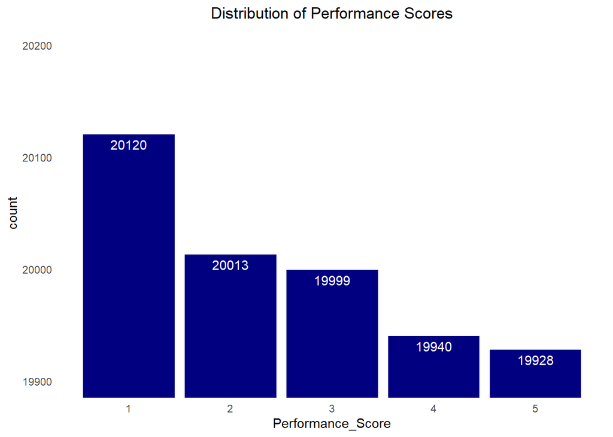

```r
#Creating a Bar Chart to investigate the distribution for performance scores
library(ggplot2) #Loading in the package ggplot2

ggplot(work, aes(x = Performance_Score)) + geom_bar(fill = "Navy") +
  coord_cartesian(ylim = c(19900, 20200)) + #Changes the y-axis viewing range
  theme_minimal() + #Changes gray background to white
  theme(panel.grid.major = element_blank(), panel.grid.minor = element_blank()) + #Removes grid
  geom_text(aes(label = ..count..), stat = "count", vjust = 1.5, color = "white") + #Labels
  ggtitle("Distribution of Performance Scores") + #Title
  theme(plot.title = element_text(hjust = 0.5)) #+ #Center Title
```

```r
  #geom_density(aes(y = Work_Hours_Per_Week))


work %>%
  count(Performance_Score)
```

```
##   Performance_Score     n
## 1                 1 20120
## 2                 2 20013
## 3                 3 19999
## 4                 4 19940
## 5                 5 19928
```

##Frequency Table for “Hours Worked” and “Performance Score” - ChatGPT

```r
#ChatGPT used to create this visualization
# Sample data: Replace this with your actual dataset
set.seed(123)
work_table <- data.frame(
  Work_Hours_Per_Week = sample(30:60, 100, replace = TRUE),
  Performance_Score = sample(1:5, 100, replace = TRUE)
)

# Define bins for Work_Hours_Per_Week
breaks <- seq(30, 60, by = 5)

# Create non-overlapping bins for Work_Hours_Per_Week
work_table$Work_Hours_Bins <- cut(work_table$Work_Hours_Per_Week, breaks = breaks, include.lowest = TRUE, right = FALSE)

# Create a contingency table for Work_Hours_Bins and Performance_Score
contingency_table <- table(work_table$Work_Hours_Bins, work_table$Performance_Score)

# Convert the contingency table to a data frame
contingency_table_df <- as.data.frame(contingency_table)
colnames(contingency_table_df) <- c("Work_Hours_Bins", "Performance_Score", "Frequency")

# Calculate the total number of observations in the dataset
total_observations <- sum(contingency_table_df$Frequency)

# Calculate overall percentages for each combination
contingency_table_df$Percentage <- (contingency_table_df$Frequency / total_observations) * 100

# Display the resulting data frame
print(contingency_table_df)
```

```
##    Work_Hours_Bins Performance_Score Frequency Percentage
## 1          [30,35)                 1         2          2
## 2          [35,40)                 1         2          2
## 3          [40,45)                 1         2          2
## 4          [45,50)                 1         2          2
## 5          [50,55)                 1         4          4
## 6          [55,60]                 1         6          6
## 7          [30,35)                 2         2          2
## 8          [35,40)                 2         2          2
## 9          [40,45)                 2         3          3
## 10         [45,50)                 2         3          3
## 11         [50,55)                 2         5          5
## 12         [55,60]                 2         5          5
## 13         [30,35)                 3         3          3
## 14         [35,40)                 3         6          6
```

[output cut: 16 more lines]

```r
# Average number of hours worked
mean(work$Work_Hours_Per_Week)
```

```
## [1] 44.95695
```

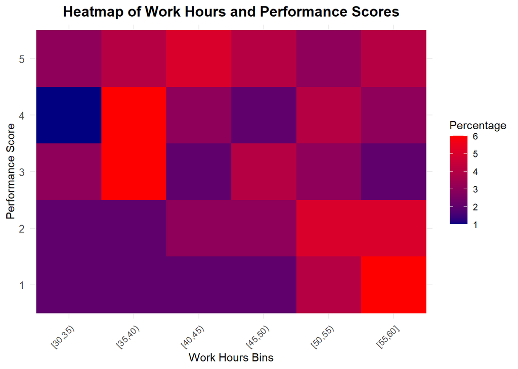

```r
##Heatmap of Frequency Table
#ChatGTP used to create this visualization
#Looking to find if "Performance_Scores" decrease as "Work Hours per Week" increases
heatmap_plot <- ggplot(contingency_table_df, aes(x = Work_Hours_Bins, y = Performance_Score, fill = Percentage)) +
  geom_tile() +
  scale_fill_gradient(low = "navy", high = "red", name = "Percentage") +
  labs(
    title = "Heatmap of Work Hours and Performance Scores",
    x = "Work Hours Bins",
    y = "Performance Score"
  ) +
  theme_minimal() +
  theme(
    axis.text.x = element_text(angle = 45, hjust = 1),
    axis.text.y = element_text(size = 10),
    plot.title = element_text(hjust = 0.5, size = 14, face = "bold")
  )

# Display the heatmap
print(heatmap_plot)
```

```r
library(ggbeeswarm)
```

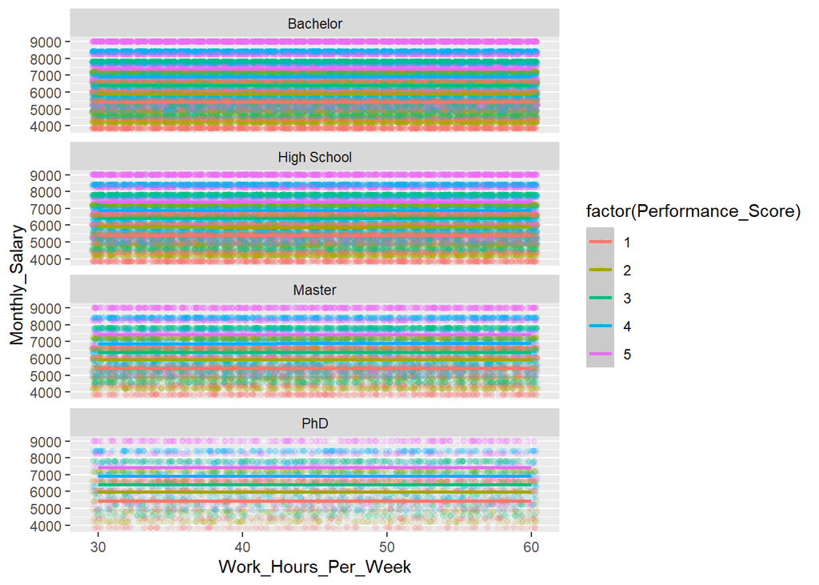

```r
ggplot(work, aes(x = Work_Hours_Per_Week, y= Monthly_Salary, color = factor(Performance_Score) )) +
  geom_jitter(alpha = 0.1) +
  geom_smooth() +
  facet_wrap(~Education_Level, nrow = 4)
```

```r
library(ggridges)
```

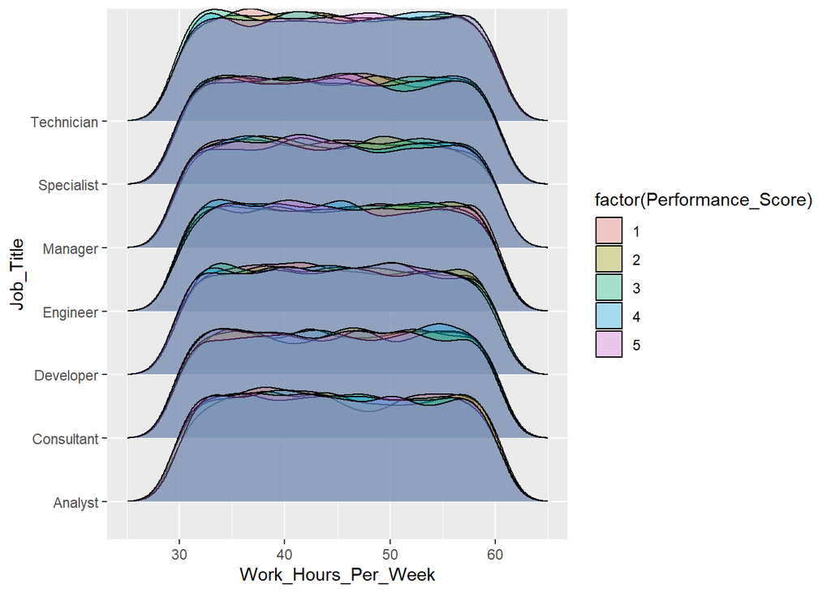

```r
ggplot(work, aes(x = Work_Hours_Per_Week, y= Job_Title, fill = factor(Performance_Score) )) +
  geom_density_ridges(alpha = 0.3)
```

##Performance_Score & Work_Hours_Per_Week

```r
#Creating a table that looks into the 'Work_Hours_Per_Week' and the count of employees 'Performance_Score' in a group
performance_workhours_tbl <- table(Performance_Score = work$Performance_Score, Work_Hours_Per_Week = work$Work_Hours_Per_Week)
print(performance_workhours_tbl)
```

```
##                  Work_Hours_Per_Week
## Performance_Score  30  31  32  33  34  35  36  37  38  39  40  41  42  43  44
##                 1 634 616 611 622 674 677 700 643 699 653 615 647 663 710 648
##                 2 629 643 624 649 637 657 649 638 701 661 654 640 604 653 648
##                 3 668 662 629 664 681 649 654 650 605 635 654 650 634 617 634
##                 4 596 662 660 690 668 625 622 639 637 669 675 637 642 663 621
##                 5 694 624 663 607 675 673 640 642 649 610 719 654 663 615 655
##                  Work_Hours_Per_Week
## Performance_Score  45  46  47  48  49  50  51  52  53  54  55  56  57  58  59
##                 1 646 610 678 622 638 631 619 661 672 645 607 658 668 595 667
##                 2 651 629 630 664 652 638 658 641 623 642 662 651 650 648 650
##                 3 623 624 688 658 617 632 664 659 654 651 646 639 633 656 644
##                 4 702 614 668 611 579 610 636 643 640 639 708 654 618 644 619
##                 5 649 675 646 613 637 657 632 618 622 608 631 614 663 654 629
##                  Work_Hours_Per_Week
## Performance_Score  60
##                 1 691
##                 2 637
##                 3 625
##                 4 649
##                 5 597
```

```r
#Converting table to df
performance_workhours_df <- as.data.frame(performance_workhours_tbl)

#Calculating the standard deviation & range of frequency between 'Work_Hours_Per_Week' and (Performance_Score = 5)
sd_5 <- sd(performance_workhours_df$Freq[which(performance_workhours_df$Performance_Score == 5)])
print(sd_5)
```

```
## [1] 27.91188
```

```r
range_5 <- range(performance_workhours_df$Freq[which(performance_workhours_df$Performance_Score == 5)])
print(range_5)
```

```
## [1] 597 719
```

```r
min_value <- range_5[1] #Extract the min and max values - Chat Used
max_value <- range_5[2]

work_hours_min <- performance_workhours_df$Work_Hours_Per_Week[performance_workhours_df$Freq == min_value] #Find the corresponding Work_Hours_Per_Week for the min and max values
work_hours_max <- performance_workhours_df$Work_Hours_Per_Week[performance_workhours_df$Freq == max_value]

print(paste("Work Hours for Min Freq:", work_hours_min)) #Print the results
```

```
## [1] "Work Hours for Min Freq: 60"
```

```r
print(paste("Work Hours for Max Freq:", work_hours_max))
```

```
## [1] "Work Hours for Max Freq: 40"
```

```r
#Calculating the standard deviation & range of frequency between 'Work_Hours_Per_Week' and (Performance_Score = 1)
sd_1 <- sd(performance_workhours_df$Freq[which(performance_workhours_df$Performance_Score == 1)])
print(sd_1)
```

```
## [1] 30.26052
```

```r
range_1 <- range(performance_workhours_df$Freq[which(performance_workhours_df$Performance_Score == 1)])
print(range_1)
```

```
## [1] 595 710
```

```r
min_value <- range_1[1] #Extract the min and max values - Chat Used
max_value <- range_1[2]

work_hours_min <- performance_workhours_df$Work_Hours_Per_Week[performance_workhours_df$Freq == min_value] #Find the corresponding Work_Hours_Per_Week for the min and max values
work_hours_max <- performance_workhours_df$Work_Hours_Per_Week[performance_workhours_df$Freq == max_value]

print(paste("Work Hours for Min Freq:", work_hours_min)) #Print the results
```

```
## [1] "Work Hours for Min Freq: 58"
```

```r
print(paste("Work Hours for Max Freq:", work_hours_max))
```

```
## [1] "Work Hours for Max Freq: 43"
```

Note/Analysis: The table & dataframe looks into the frequency distribution for each performance score level and each Work Hours Per Week. Having said that, when focusing on only the 5-Rating Performance Score level, the standard deviation of the frequency is 27.91. In other words, the number of employees with a Performance score of 5 does not significantly change as Work_Hours_Per_Week increases. The most 5-Rating Performance Score levels comes from working 40 hours per week.

Overall, the number of hours worked per week does not seem to heavily influence performance scores.

```r
vals <- unique(work$Work_Hours_Per_Week)
m_perf <- rep(NA, length(vals))
for(i in 1:length(vals)){
  m_perf[i] <- mean(work$Performance_Score[which(work$Work_Hours_Per_Week == vals[i])], na.rm = TRUE)
}
```

##Random Forest

```r
#Performing random forest. Random forest is a ML learning technique that builds decision trees to make predictions
library(randomForest)
rf <- randomForest(Performance_Score~.-Employee_ID,data=work, do.trace=TRUE, ntree = 100)
```

```
##      |      Out-of-bag   |
## Tree |      MSE  %Var(y) |
##    1 |  0.05105     2.55 |
##    2 |  0.06183     3.09 |
##    3 |   0.1192     5.96 |
##    4 |  0.08808     4.40 |
##    5 |  0.08224     4.11 |
##    6 |  0.07917     3.96 |
##    7 |  0.07853     3.92 |
##    8 |  0.08602     4.30 |
##    9 |  0.07134     3.56 |
##   10 |  0.06249     3.12 |
##   11 |  0.05503     2.75 |
##   12 |  0.04743     2.37 |
##   13 |  0.04089     2.04 |
```

[output cut: 87 more lines]

```r
#Making a graph for the random forest feature
randomForest::varImpPlot(rf, main = "Performance Score Variable Importance")
```

[output not shown]

```r
partialPlot(rf, x.var = "Monthly_Salary", pred.data = work)
```

[output not shown]

```r
#Making another randomForest model, but removing 'Monthly_Salary' and 'Job_Title' from the Model to see if other variables have some value
rf_adjust <- randomForest(Performance_Score~.-Monthly_Salary-Job_Title-Employee_ID,data=work, do.trace=TRUE, ntree = 100)
```

```
##      |      Out-of-bag   |
## Tree |      MSE  %Var(y) |
##    1 |    3.883   194.03 |
##    2 |    3.661   182.91 |
##    3 |    3.474   173.55 |
##    4 |    3.298   164.80 |
##    5 |    3.142   156.97 |
##    6 |     3.01   150.40 |
##    7 |    2.887   144.27 |
##    8 |    2.789   139.37 |
##    9 |    2.701   134.97 |
##   10 |    2.628   131.29 |
##   11 |     2.57   128.41 |
##   12 |    2.515   125.66 |
##   13 |    2.469   123.38 |
```

[output cut: 87 more lines]

```r
randomForest::varImpPlot(rf_adjust, main = "Performance Score Variable Importance")
```

[output not shown]

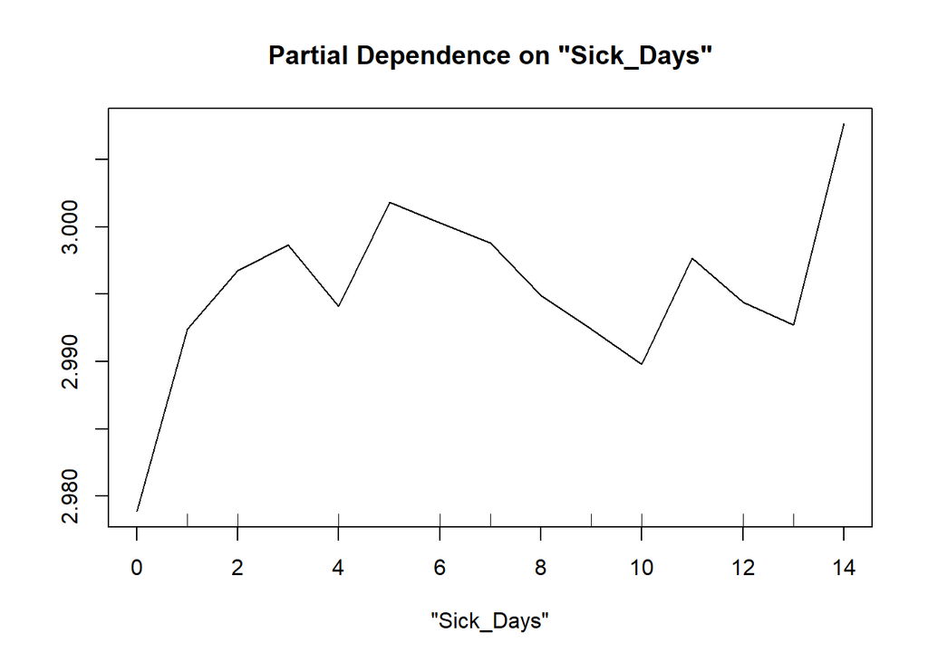

```r
partialPlot(rf_adjust, x.var = "Sick_Days", pred.data = work)
```

```r
#More Random Forest. Looking into 'Sick_Days' as response
rf_sick <- randomForest(Sick_Days~.-Employee_ID,data=work, do.trace=TRUE, ntree = 100)
```

```
##      |      Out-of-bag   |
## Tree |      MSE  %Var(y) |
##    1 |    36.13   192.57 |
##    2 |     34.4   183.36 |
##    3 |    32.51   173.25 |
##    4 |    30.82   164.29 |
##    5 |    29.37   156.52 |
##    6 |    28.22   150.39 |
##    7 |    27.09   144.37 |
##    8 |    26.17   139.47 |
##    9 |    25.32   134.93 |
##   10 |    24.68   131.54 |
##   11 |    24.07   128.29 |
##   12 |     23.6   125.77 |
##   13 |    23.18   123.55 |
```

[output cut: 87 more lines]

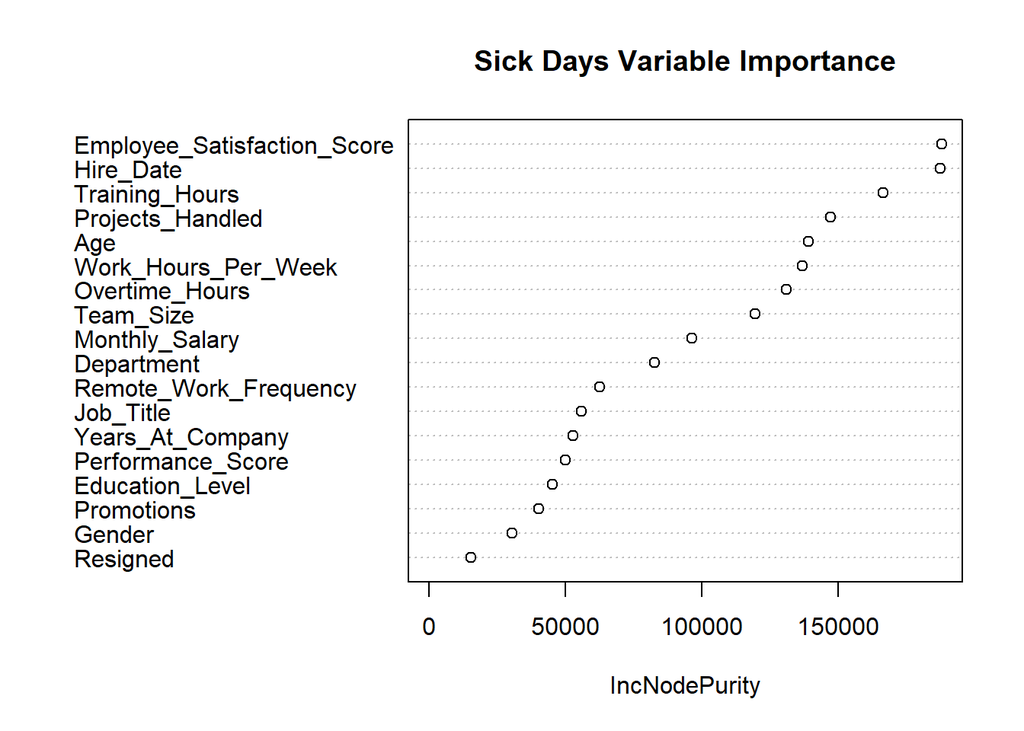

```r
randomForest::varImpPlot(rf_sick, main = "Sick Days Variable Importance")
```

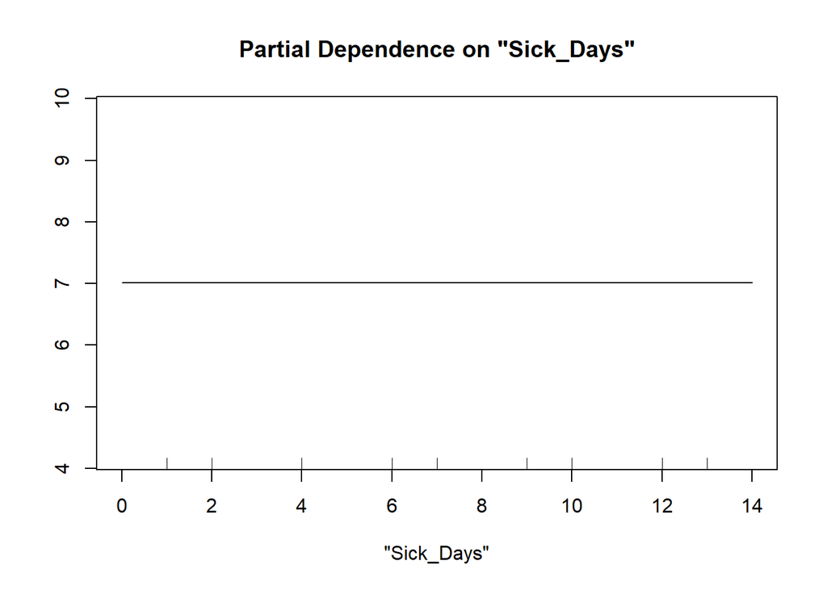

```r
partialPlot(rf_sick, x.var = "Sick_Days", pred.data = work)
```

```r
#More Random Forest. Looking into 'Employee_Satisfaction_Score' as response
rf_satisfaction <- randomForest(Employee_Satisfaction_Score~.-Employee_ID,data=work, do.trace=TRUE, ntree=100)
```

```
##      |      Out-of-bag   |
## Tree |      MSE  %Var(y) |
##    1 |    2.576   194.54 |
##    2 |    2.439   184.22 |
##    3 |    2.307   174.20 |
##    4 |     2.19   165.43 |
##    5 |    2.087   157.62 |
##    6 |    1.998   150.91 |
##    7 |    1.919   144.92 |
##    8 |    1.853   139.98 |
##    9 |      1.8   135.97 |
##   10 |    1.751   132.24 |
##   11 |    1.707   128.92 |
##   12 |    1.669   126.07 |
##   13 |     1.64   123.86 |
```

[output cut: 87 more lines]

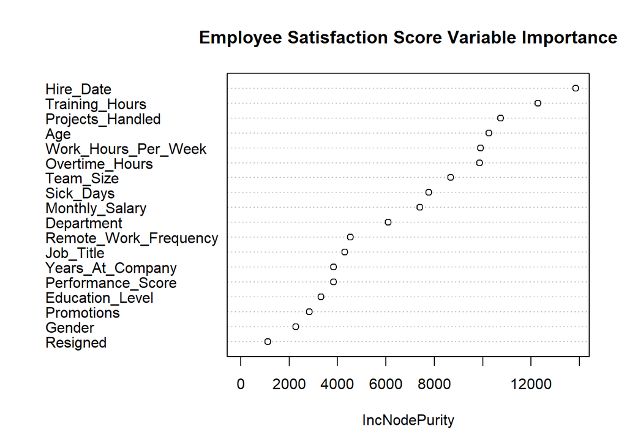

```r
randomForest::varImpPlot(rf_satisfaction, main = "Employee Satisfaction Score Variable Importance")
```

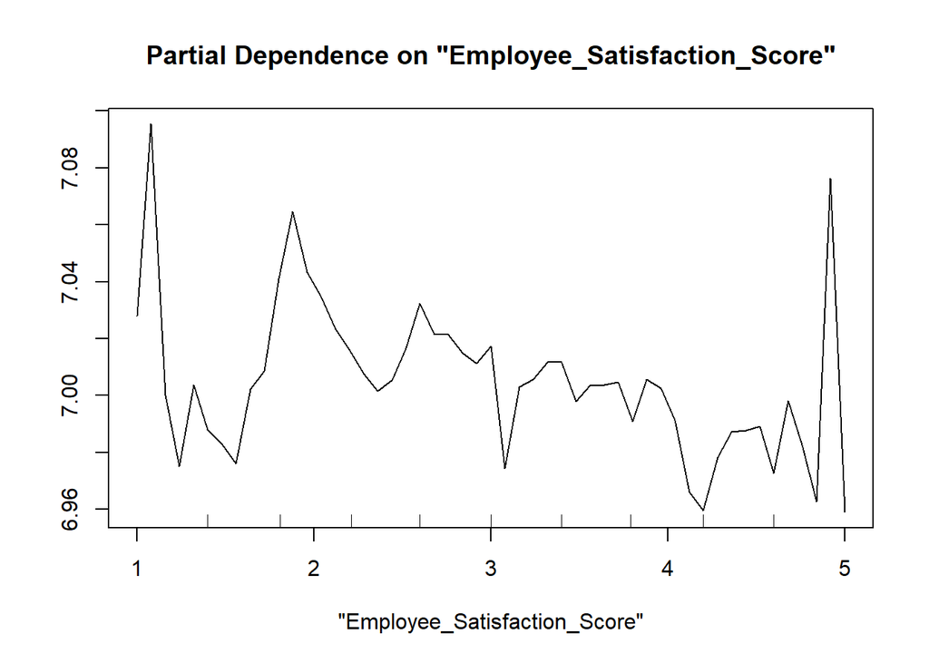

```r
partialPlot(rf_sick, x.var = "Employee_Satisfaction_Score", pred.data = work)
```

```r
#Making a graph for the random forest feature
randomForest::varImpPlot(rf, main = "Performance Score Variable Importance")
```

[output not shown]

```r
partialPlot(rf, x.var = "Monthly_Salary", pred.data = work)
```

[output not shown]

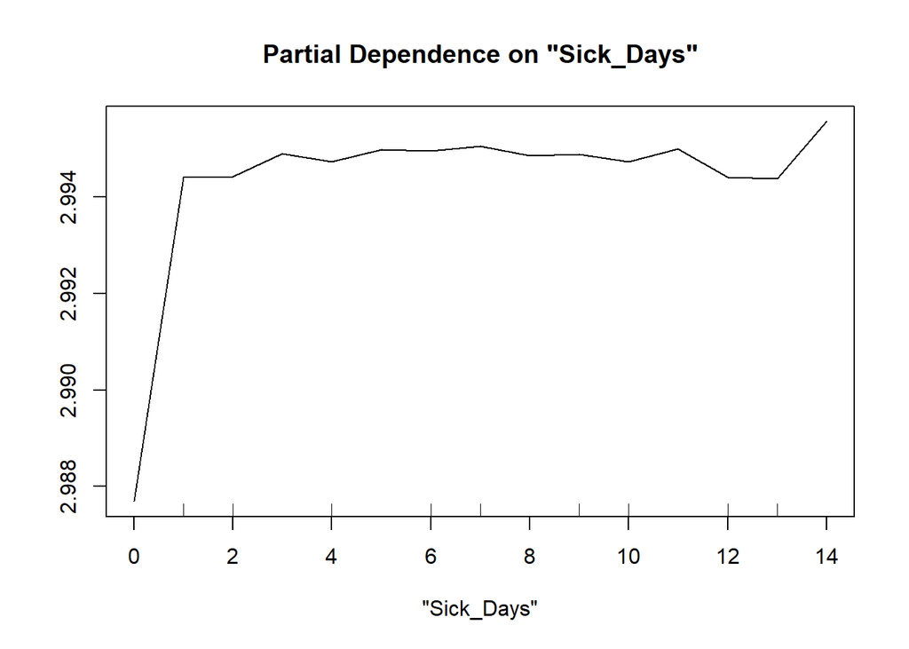

```r
partialPlot(rf, x.var = "Sick_Days", pred.data = work)
```

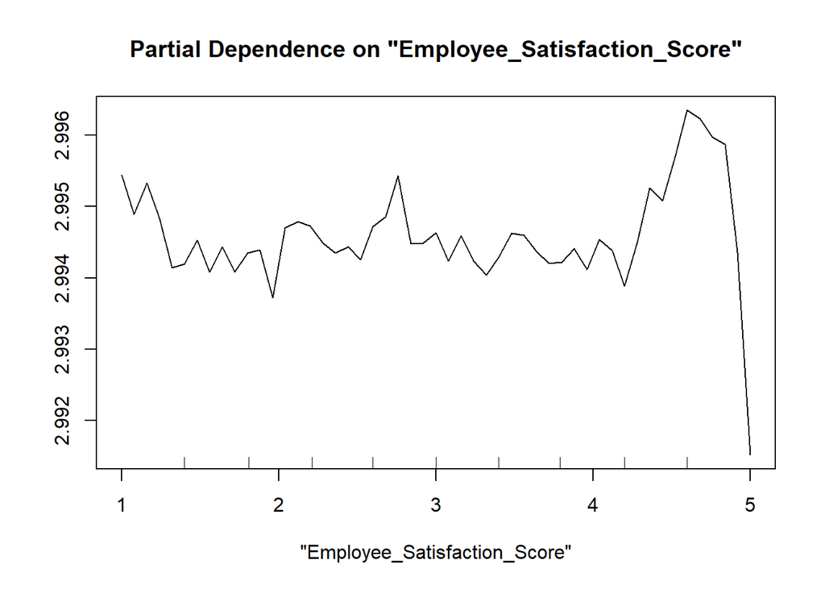

```r
partialPlot(rf, x.var = "Employee_Satisfaction_Score", pred.data = work)
```

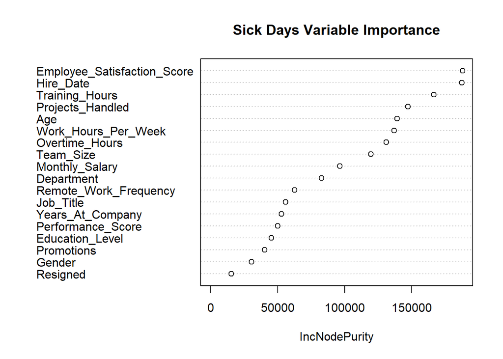

```r
randomForest::varImpPlot(rf_sick, main = "Sick Days Variable Importance")
```

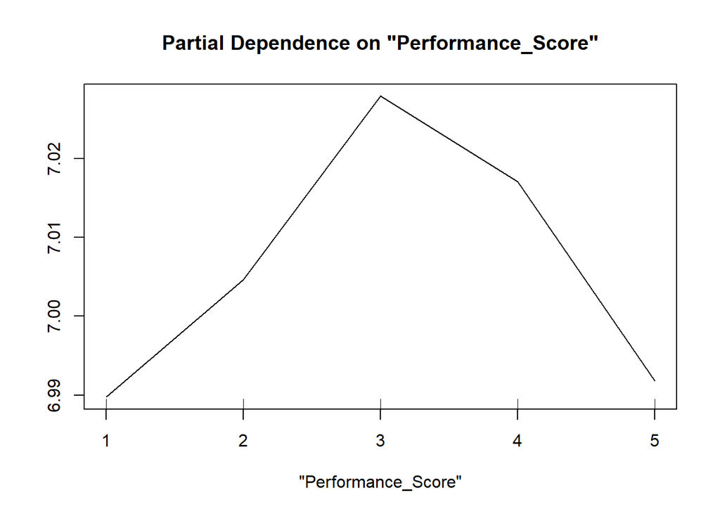

```r
partialPlot(rf_sick, x.var = "Performance_Score", pred.data = work)
```

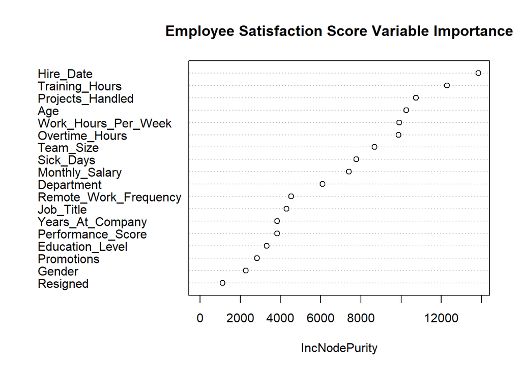

```r
randomForest::varImpPlot(rf_satisfaction, main = "Employee Satisfaction Score Variable Importance")
```

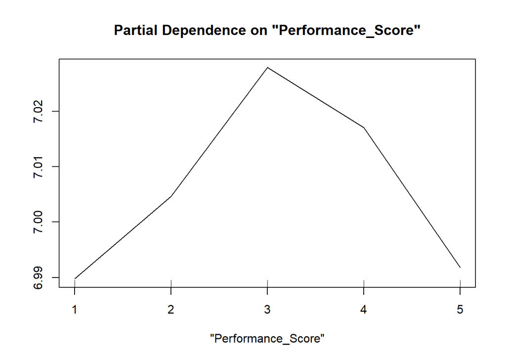

```r
partialPlot(rf_sick, x.var = "Performance_Score", pred.data = work)
```

```r
randomForest::varImpPlot(rf, main = "Performance Score Variable Importance")
```

[output not shown]

```r
partialPlot(rf, x.var = "Monthly_Salary", pred.data = work)
```

[output not shown]

```r
randomForest::varImpPlot(rf_adjust, main = "Performance Score Variable Importance")
```

[output not shown]

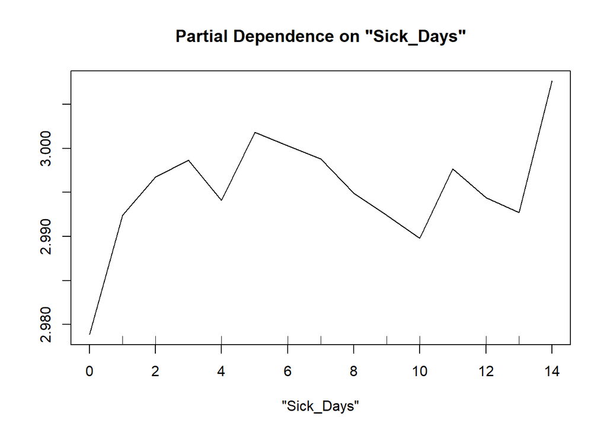

```r
partialPlot(rf_adjust, x.var = "Sick_Days", pred.data = work)
```

```r
randomForest::varImpPlot(rf_adjust, main = "Performance Score Variable Importance")
```

[output not shown]

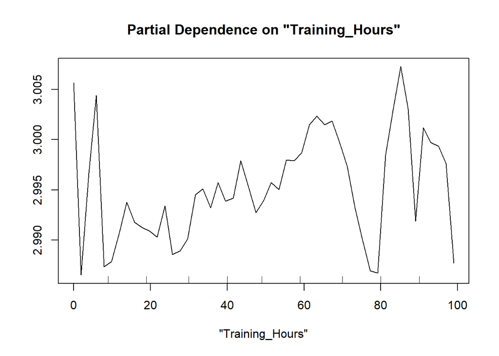

```r
partialPlot(rf_adjust, x.var = "Training_Hours", pred.data = work)
```

Note/Analysis: Monthly Salary and Job_Title appear to be the most important in predicting Performance Score. Logically that checks out. The more an employee is being paid, performance should increase. As for Job_Title, this makes sense also. People with a lower job, for example working at Chick-Fil-A as a server, likely do not input the same effort and energy relative to that of a CEO at Apple.

Because ‘Monthly_Salary’ and ‘Job_Title’ were so significant in the model, a model was built excluding them (rf_adjust). With this model, other variables such as ‘Employee_Satisfaction_Score’ appear to be more important in predicting ‘Performance_Score’. Having said that, when looking at the Partial Plots the changes are little (Changes in tenths, hundreths).

##Looking into Education Level and Performance Score

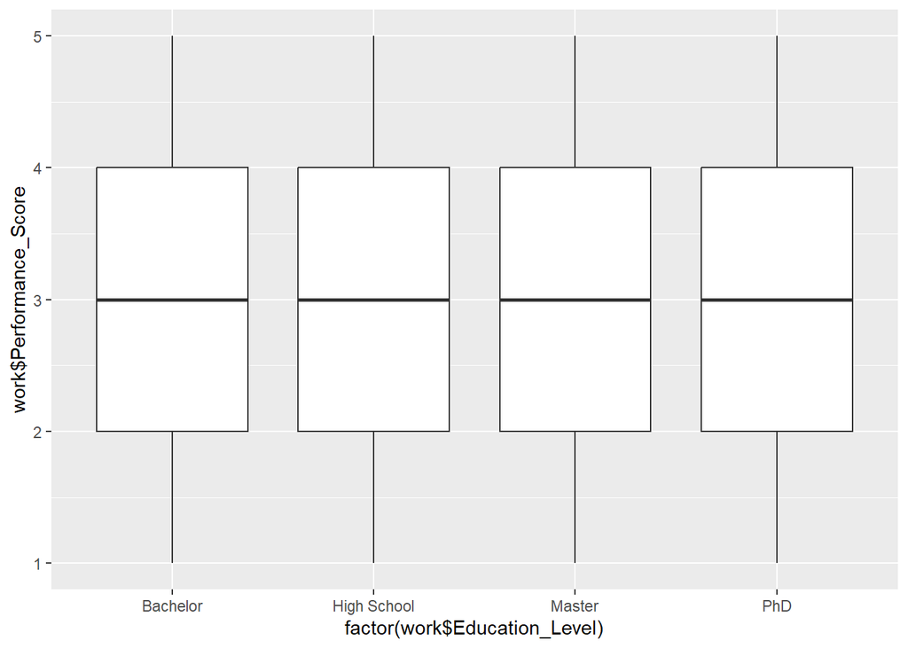

```r
ggplot(work, aes(x=factor(work$Education_Level), y = work$Performance_Score)) +
  geom_boxplot()
```

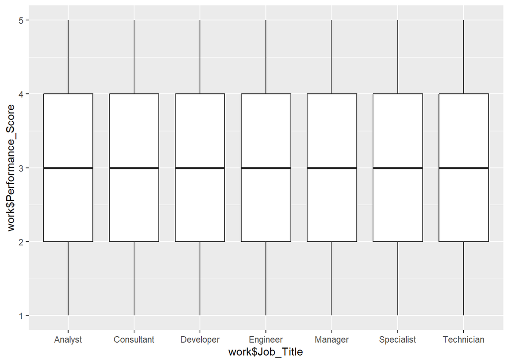

```r
#Looking into job_title and Performance_Score
ggplot(work, aes(x=work$Job_Title, y = work$Performance_Score)) +
  geom_boxplot()
```

##XgBoost Model

```r
#Set seed to get same output for sequence of numbers
set.seed(7)

#Split the data into test and training sets
portion <- createDataPartition(work$Performance_Score, p = 0.70, list = F)
train_work <- work[portion, ]
test_work <- work[-portion, ]

#define predictor and response variables in training set
train_x = data.matrix(train_work[, -9])
train_y = train_work[,9]

#define predictor and response variables in testing set
test_x = data.matrix(test_work[, -9])
test_y = test_work[, 9]

#define final training and testing sets
xgb_train = xgb.DMatrix(data = train_x, label = train_y)
xgb_test = xgb.DMatrix(data = test_x, label = test_y)

#define watchlist
watchlist = list(train=xgb_train, test=xgb_test)

#fit XGBoost model and display training and testing data at each round
model = xgb.train(data = xgb_train, max.depth = 3, watchlist=watchlist, nrounds = 200)
```

[output not shown]

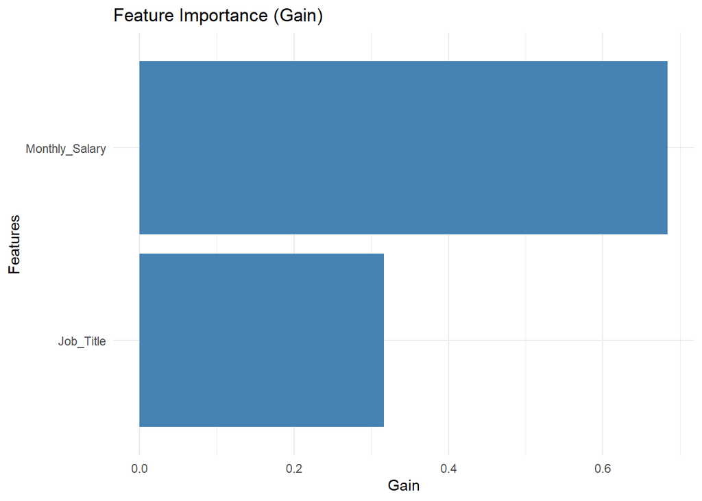

```r
#Note: 0.000039 is the minimal test-rmse. This happens at the 145 round.

#define final model
final = xgboost(data = xgb_train, max.depth = 3, nrounds = 145, verbose = 0)

#Finding feature importance
feature_importance <- xgb.importance(model = final)

#Custom visualization with ggplot2 - Geeks for geeks code
feature_importance <- feature_importance %>% arrange(desc(Gain))

ggplot(feature_importance, aes(x = reorder(Feature, Gain), y = Gain)) +
  geom_bar(stat = "identity", fill = "steelblue") +
  coord_flip() +
  labs(title = "Feature Importance (Gain)", x = "Features", y = "Gain") +
  theme_minimal()
```

##What factors influence Monthly Salary? + XgBoost Model 2

```r
#Set seed to get same output for sequence of numbers
set.seed(7)

#Split the data into test and training sets
portion2 <- createDataPartition(work$Monthly_Salary, p = 0.70, list = F)
train_work2 <- work[portion2, ]
test_work2 <- work[-portion2, ]

#define predictor and response variables in training set
train_x2 = data.matrix(train_work2[, -10])
train_y2 = train_work2[,10]

#define predictor and response variables in testing set
test_x2 = data.matrix(test_work2[, -10])
test_y2 = test_work2[, 10]

#define final training and testing sets
xgb_train2 = xgb.DMatrix(data = train_x2, label = train_y2)
xgb_test2 = xgb.DMatrix(data = test_x2, label = test_y2)

#define watchlist
watchlist2 = list(train=xgb_train2, test=xgb_test2)

#fit XGBoost model and display training and testing data at each round
model2 = xgb.train(data = xgb_train2, max.depth = 5, watchlist=watchlist2, nrounds = 400)
```

[output not shown]

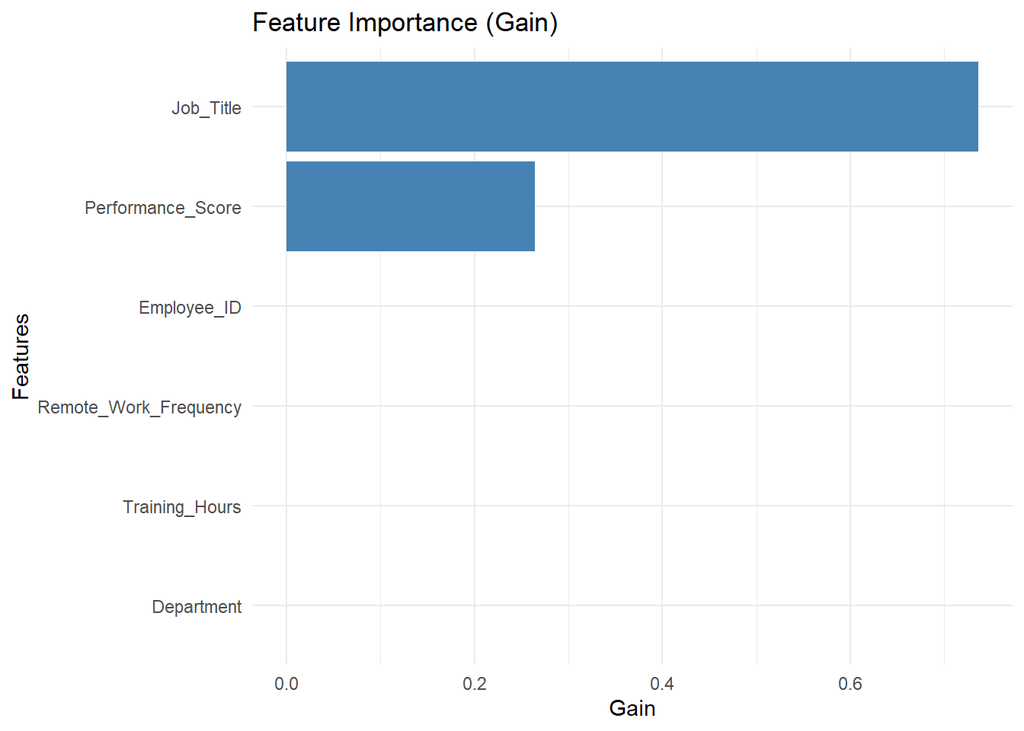

```r
#Note: 0.0000686 is the minimal test-rmse. This happens at the 67 round.

#define final model
final2 = xgboost(data = xgb_train2, max.depth = 5, nrounds = 67, verbose = 0)

#Finding feature importance
feature_importance2 <- xgb.importance(model = final2)

#Custom visualization with ggplot2 - Geeks for geeks code
feature_importance2 <- feature_importance2 %>% arrange(desc(Gain))

ggplot(feature_importance2, aes(x = reorder(Feature, Gain), y = Gain)) +
  geom_bar(stat = "identity", fill = "steelblue") +
  coord_flip() +
  labs(title = "Feature Importance (Gain)", x = "Features", y = "Gain") +
  theme_minimal()
```

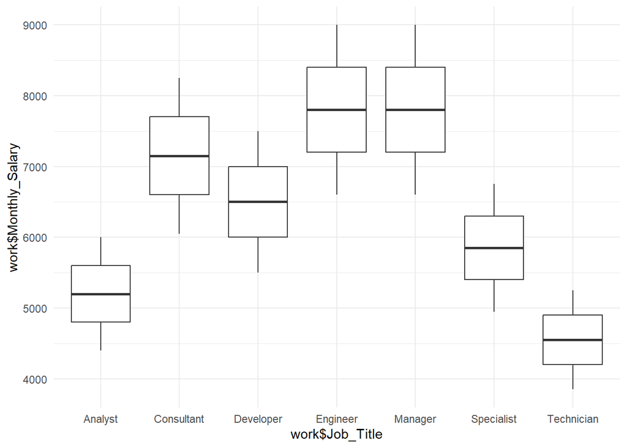

```r
#Building a boxplot for job titles
ggplot(work, aes(x = work$Job_Title, y = work$Monthly_Salary)) +
  geom_boxplot() +
  theme_minimal()
```

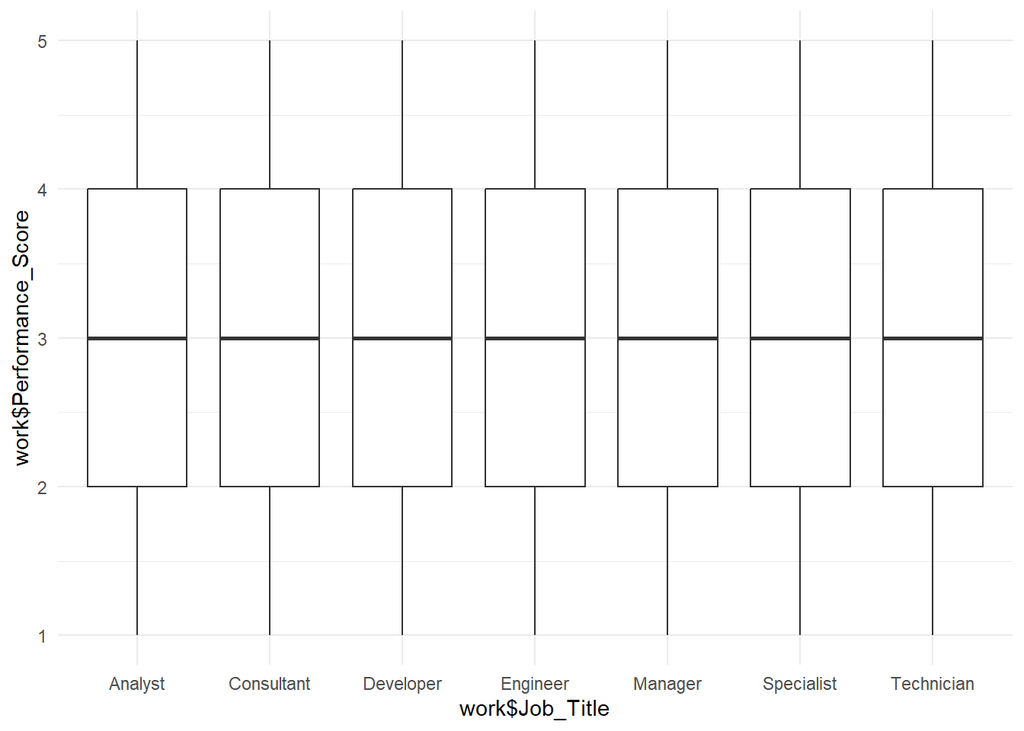

```r
ggplot(work, aes(x = work$Job_Title, y = work$Performance_Score)) +
  geom_boxplot() +
  theme_minimal()
```

Note/Analysis: Correlation does not equal causation. The XgBoost model reflects that Job Title and Performance Score contribute the most to Monthly Salary. Having said that, it is difficult, if not impossible to label which factor ‘motivates’ the other. People with a better job title naturally have a better salary. One could argue, to get a better salary, get a better job title. But the argument, work harder to get a better job title, to get a better salary, could be made also. The boxplot reflects that naturally certain job titles will earn a better salary.